# Store 24(A)

Parv Patni

December 18, 2017

```r
getwd()
```

```
## [1] "C:/Users/parvp/Desktop/data analytics internship"
```

```r
store <- read.csv(paste("Store24.csv", sep=""))
head(store)
```

```
##   store   Sales Profit   MTenure   CTenure   Pop     Comp Visibility
## 1     1 1060294 265014   0.00000 24.804930  7535 2.797888          3
## 2     2 1619874 424007  86.22219  6.636550  8630 4.235555          4
## 3     3 1099921 222735  23.88854  5.026694  9695 4.494666          3
## 4     4 1053860 210122   0.00000  5.371663  2797 4.253946          4
## 5     5 1227841 300480   3.87737  6.866530 20335 1.651364          2
## 6     6 1703140 469050 149.93590 11.351130 16926 3.184613          3
##   PedCount Res Hours24 CrewSkill MgrSkill  ServQual
## 1        3   1       1      3.56 3.150000  86.84327
## 2        3   1       1      3.20 3.556667  94.73510
## 3        3   1       1      3.80 4.116667  78.94776
## 4        2   1       1      2.06 4.100000 100.00000
## 5        5   0       1      3.65 3.588889  68.42164
## 6        4   1       0      3.58 4.605556  94.73510
```

```r
summary(store)
```

```
##      store          Sales             Profit          MTenure
##  Min.   : 1.0   Min.   : 699306   Min.   :122180   Min.   :  0.00
##  1st Qu.:19.5   1st Qu.: 984579   1st Qu.:211004   1st Qu.:  6.67
##  Median :38.0   Median :1127332   Median :265014   Median : 24.12
##  Mean   :38.0   Mean   :1205413   Mean   :276314   Mean   : 45.30
##  3rd Qu.:56.5   3rd Qu.:1362388   3rd Qu.:331314   3rd Qu.: 50.92
##  Max.   :75.0   Max.   :2113089   Max.   :518998   Max.   :277.99
##     CTenure              Pop             Comp          Visibility
##  Min.   :  0.8871   Min.   : 1046   Min.   : 1.651   Min.   :2.00
##  1st Qu.:  4.3943   1st Qu.: 5616   1st Qu.: 3.151   1st Qu.:3.00
##  Median :  7.2115   Median : 8896   Median : 3.629   Median :3.00
##  Mean   : 13.9315   Mean   : 9826   Mean   : 3.788   Mean   :3.08
##  3rd Qu.: 17.2156   3rd Qu.:14104   3rd Qu.: 4.230   3rd Qu.:4.00
##  Max.   :114.1519   Max.   :26519   Max.   :11.128   Max.   :5.00
##     PedCount         Res          Hours24       CrewSkill
##  Min.   :1.00   Min.   :0.00   Min.   :0.00   Min.   :2.060
##  1st Qu.:2.00   1st Qu.:1.00   1st Qu.:1.00   1st Qu.:3.225
##  Median :3.00   Median :1.00   Median :1.00   Median :3.500
##  Mean   :2.96   Mean   :0.96   Mean   :0.84   Mean   :3.457
##  3rd Qu.:4.00   3rd Qu.:1.00   3rd Qu.:1.00   3rd Qu.:3.655
##  Max.   :5.00   Max.   :1.00   Max.   :1.00   Max.   :4.640
##     MgrSkill        ServQual
##  Min.   :2.957   Min.   : 57.90
##  1st Qu.:3.344   1st Qu.: 78.95
##  Median :3.589   Median : 89.47
##  Mean   :3.638   Mean   : 87.15
##  3rd Qu.:3.925   3rd Qu.: 99.90
##  Max.   :4.622   Max.   :100.00
```

mean and standards deviations of Profit

```r
mean(store$Profit)
```

```
## [1] 276313.6
```

```r
sd(store$Profit)
```

```
## [1] 89404.08
```

mean and standard deviation of MTenure.

```r
mean(store$MTenure)
```

```
## [1] 45.29644
```

```r
sd(store$MTenure)
```

```
## [1] 57.67155
```

mean and standard deviation of CTenure.

```r
mean(store$CTenure)
```

```
## [1] 13.9315
```

```r
sd(store$CTenure)
```

```
## [1] 17.69752
```

Top 10 most profitable stores.

```r
attach(store)
exhib1 <- store[order(-Profit),]
exhib1[1:10,1:5]
```

```
##    store   Sales Profit   MTenure    CTenure
## 74    74 1782957 518998 171.09720  29.519510
## 7      7 1809256 476355  62.53080   7.326488
## 9      9 2113089 474725 108.99350   6.061602
## 6      6 1703140 469050 149.93590  11.351130
## 44    44 1807740 439781 182.23640 114.151900
## 2      2 1619874 424007  86.22219   6.636550
## 45    45 1602362 410149  47.64565   9.166325
## 18    18 1704826 394039 239.96980  33.774130
## 11    11 1583446 389886  44.81977   2.036961
## 47    47 1665657 387853  12.84790   6.636550
```

Top 10 least profitable stores

```r
exhib1 <- store[order(Profit),]
exhib1[1:10,1:5]
```

```
##    store   Sales Profit     MTenure   CTenure
## 57    57  699306 122180  24.3485700  2.956879
## 66    66  879581 146058 115.2039000  3.876797
## 41    41  744211 147327  14.9180200 11.926080
## 55    55  925744 147672   6.6703910 18.365500
## 32    32  828918 149033  36.0792600  6.636550
## 13    13  857843 152513   0.6571813  1.577002
## 54    54  811190 159792   6.6703910  3.876797
## 52    52 1073008 169201  24.1185600  3.416838
## 61    61  716589 177046  21.8184200 13.305950
## 37    37 1202917 187765  23.1985000  1.347023
```

Plot of Profit vs MTenure

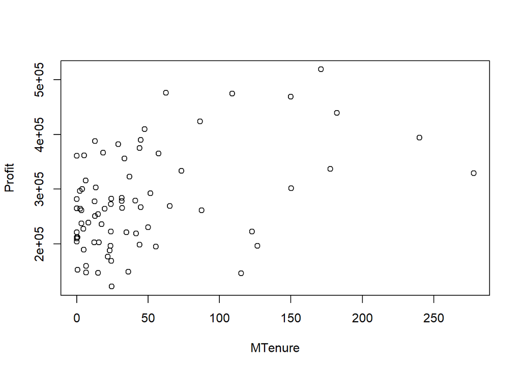

```r
plot(MTenure,Profit)
```

Plot of Profit vs CTenure

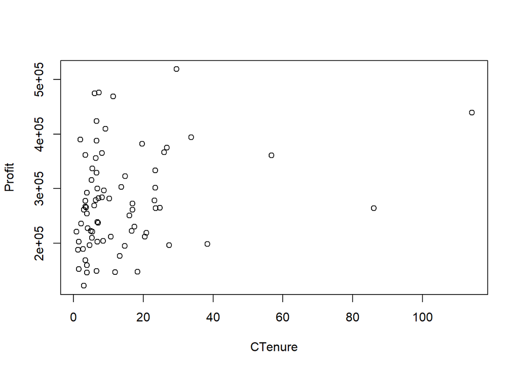

```r
plot(CTenure,Profit)
```

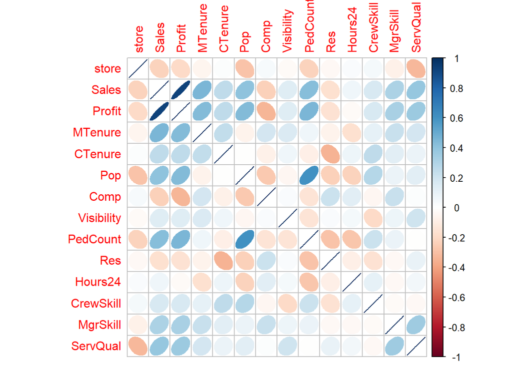

```r
library(corrplot)
corrplot(corr=cor(store[ , c(1:14)], use="complete.obs"),
         method ="ellipse")
```

```r
cor(store$Profit,store$MTenure)
```

```
## [1] 0.4388692
```

Correlation between Profit and CTenure

```r
cor(store$Profit,store$CTenure)
```

```
## [1] 0.2576789
```

Corrgram of all the variables

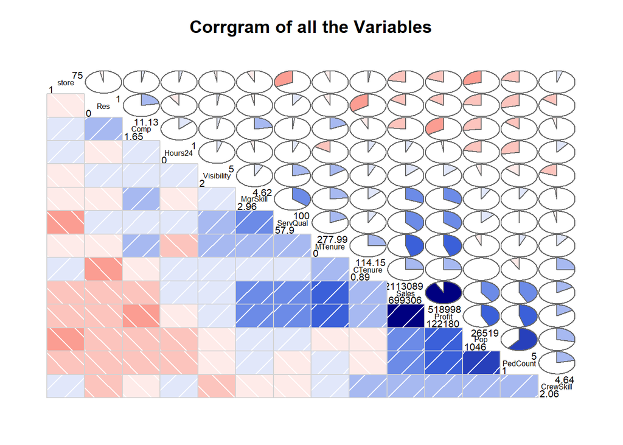

```r
library(corrgram)
corrgram(store, order=TRUE,
         main="Corrgram of all the Variables",
         lower.panel=panel.shade, upper.panel=panel.pie,
         diag.panel=panel.minmax, text.panel=panel.txt)
```

Correlation test between Profit and CTenure

```r
cor.test(store$Profit,store$CTenure)
```

```
##
##  Pearson's product-moment correlation
##
## data:  store$Profit and store$CTenure
## t = 2.2786, df = 73, p-value = 0.02562
## alternative hypothesis: true correlation is not equal to 0
## 95 percent confidence interval:
##  0.03262507 0.45786339
## sample estimates:
##       cor
## 0.2576789
```

The p - Value is 0.02562.

Regression of Profit on {MTenure, CTenure, Comp, Pop, PedCount, Res, Hours24, Visibility}

```r
regr <- lm(Profit ~ MTenure + CTenure + Comp + Pop + PedCount + Res + Hours24 + Visibility, data = store)
summary(regr)
```

```
##
## Call:
## lm(formula = Profit ~ MTenure + CTenure + Comp + Pop + PedCount +
##     Res + Hours24 + Visibility, data = store)
##
## Residuals:
##     Min      1Q  Median      3Q     Max
## -105789  -35946   -7069   33780  112390
##
## Coefficients:
##               Estimate Std. Error t value Pr(>|t|)
## (Intercept)   7610.041  66821.994   0.114 0.909674
## MTenure        760.993    127.086   5.988 9.72e-08 ***
## CTenure        944.978    421.687   2.241 0.028400 *
## Comp        -25286.887   5491.937  -4.604 1.94e-05 ***
## Pop              3.667      1.466   2.501 0.014890 *
## PedCount     34087.359   9073.196   3.757 0.000366 ***
## Res          91584.675  39231.283   2.334 0.022623 *
## Hours24      63233.307  19641.114   3.219 0.001994 **
## Visibility   12625.447   9087.620   1.389 0.169411
## ---
## Signif. codes:  0 '***' 0.001 '**' 0.01 '*' 0.05 '.' 0.1 ' ' 1
##
## Residual standard error: 56970 on 66 degrees of freedom
## Multiple R-squared:  0.6379, Adjusted R-squared:  0.594
## F-statistic: 14.53 on 8 and 66 DF,  p-value: 5.382e-12
```

```r
regr$coefficients
```

```
##   (Intercept)       MTenure       CTenure          Comp           Pop
##   7610.041452    760.992734    944.978026 -25286.886662      3.666606
##      PedCount           Res       Hours24    Visibility
##  34087.358789  91584.675234  63233.307162  12625.447050
```

```r
residuals(regr)
```

```
##            1            2            3            4            5
##  -17870.5566  112390.4448  -24652.2001   21254.9195   -8292.9911
##            6            7            8            9           10
##   89270.7785   84050.0803  -10870.2458   31488.0240  -21849.6437
##           11           12           13           14           15
##    -528.7222  -91759.0426  -57806.5916   -7068.7877  -75345.2520
##           16           17           18           19           20
##   -6104.0234  -86950.2209  -61254.3355    5413.3764   -5853.2921
##           21           22           23           24           25
##    5094.0156   95869.5511  -31589.1824   53013.4120   36072.8170
##           26           27           28           29           30
##   -7386.9737  -28735.7167   -7662.9590   53111.6789   73572.1725
##           31           32           33           34           35
##   14802.3715  -42214.3885   85510.4023   11712.8399    3995.3758
##           36           37           38           39           40
##  -13036.0714  -52665.8054    4157.3337  -39500.8957   49125.8347
##           41           42           43           44           45
##  -90438.9845  -13683.5771  -38699.0221  -35704.8151   59928.2412
##           46           47           48           49           50
##   36388.7486  -11664.7868   75418.5740  -20696.9041  -56799.7045
##           51           52           53           54           55
##  -45563.7849  -42912.6649  112306.9000  -36187.6388  -67002.3454
##           56           57           58           59           60
##   22171.0985 -105788.7112    9050.7093   38001.1613   24195.2780
##           61           62           63           64           65
##  -15038.1182  -16284.7396     509.1427  -97461.0600    8243.7616
##           66           67           68           69           70
##  -72921.5481  100520.7352   -4625.3831   95310.5717  -27907.3903
##           71           72           73           74           75
##   -7364.0084  -65662.7214    9331.0473  106126.6026   43997.8062
```

## Summary

3.The most profitable store is with ID:74 and the least profitable store is :57

5.stores located in industrial areas generally have a high employee retention and skill rate. Hence, any employee retention programme must primarily be focused in stores located in resedential areas.

6.Coming to the regression part,the p-value of the model is statistically significant.It means it is a good fit model.

7.R square value is:0.6379.It means that 63.79% of variations in the dependent variable is explained by the independent variable.

8.Adjusted R square value is 0.594.It means 59.4% variation in the dependent variable is explained by the independent variable.This values decreases as we add no of independent variables.

9.Variables MTenure, Comp, PedCount, Hours24, CTenure, Pop, Res are Statistically significant with p<0.05.

10.Variable Visibility is statistically insignificant with p>0.05.